# Valorant Esports Meta Analysis

JOLYNECUJOH233

2026-03-24

## Required packages

```r
library(tidyverse)
library(lubridate)
library(scales)
library(sf)
library(tmap)
library(maptiles)
library(ggrepel)
library(ggridges)

theme_set(theme_minimal(base_size = 12))

pal <- c(
  nus_blue   = "#003D7C",
  blue       = "#2E75B6",
  nus_orange = "#EF7C00",
  ice        = "#D6E8F7",
  grey       = "#6B7D8C"
)
```

Install packages that do not yet have via the *console*:

```r
install.packages(c("sf", "tmap", "maptiles", "ggrepel"))
```

# Valorant Esports Meta Analysis

```r
library(ggridges)


pick_rates <- map_dfr(2021:2024, function(yr) {
  read_csv(
    paste0("data/archive/vct_", yr, "/agents/agents_pick_rates.csv"),
    show_col_types = FALSE
  ) %>% mutate(year = yr)
})

maps_stats <- map_dfr(2021:2024, function(yr) {
  read_csv(
    paste0("data/archive/vct_", yr, "/agents/maps_stats.csv"),
    show_col_types = FALSE
  ) %>% mutate(year = yr)
})


cat("=== pick_rates line ===\n")
```

```
## === pick_rates line ===
```

```r
glimpse(pick_rates)
```

```
## Rows: 367,008
## Columns: 7
## $ Tournament   <chr> "Champions Tour North America: Last Chance Qualifier", "C…
## $ Stage        <chr> "Main Event", "Main Event", "Main Event", "Main Event", "…
## $ `Match Type` <chr> "Upper Quarterfinals", "Upper Quarterfinals", "Upper Quar…
## $ Map          <chr> "All Maps", "All Maps", "All Maps", "All Maps", "All Maps…
## $ Agent        <chr> "jett", "sova", "viper", "skye", "astra", "cypher", "sage…
## $ `Pick Rate`  <chr> "91%", "77%", "68%", "64%", "55%", "32%", "27%", "27%", "…
## $ year         <int> 2021, 2021, 2021, 2021, 2021, 2021, 2021, 2021, 2021, 202…
```

```r
cat("\n=== maps_stats line ===\n")
```

```
##
## === maps_stats line ===
```

```r
glimpse(maps_stats)
```

```
## Rows: 15,292
## Columns: 8
## $ Tournament                     <chr> "Champions Tour North America: Last Cha…
## $ Stage                          <chr> "Main Event", "Main Event", "Main Event…
## $ `Match Type`                   <chr> "Upper Quarterfinals", "Upper Quarterfi…
## $ Map                            <chr> "All Maps", "Breeze", "Ascent", "Icebox…
## $ `Total Maps Played`            <dbl> 11, 3, 2, 2, 2, 1, 1, 6, 2, 2, 1, 1, 3,…
## $ `Attacker Side Win Percentage` <chr> "46%", "61%", "36%", "54%", "30%", "55%…
## $ `Defender Side Win Percentage` <chr> "54%", "39%", "64%", "46%", "70%", "45%…
## $ year                           <int> 2021, 2021, 2021, 2021, 2021, 2021, 202…
```

## Valorant Esports Meta Analysis — What defines the professional meta?

### Introduction

This analysis explores the Valorant Champions Tour (VCT) dataset from 2021 to 2024, covering professional esports matches across all major tournaments. The central research question is: **which agents dominate the professional meta, and how balanced are Valorant’s maps in terms of attacker vs defender advantage?**

Unlike casual play, professional matches reflect highly optimised strategies, making this dataset a useful lens for understanding game balance — a key concern for both developers and competitive players.

Data source: VCT match data scraped from VLR.gg, available on Kaggle.

### Data loading and preprocessing

```r
library(ggridges)

# Load and combine agent pick rates across years
pick_rates <- map_dfr(2021:2024, function(yr) {
  read_csv(
    paste0("data/archive/vct_", yr, "/agents/agents_pick_rates.csv"),
    show_col_types = FALSE
  ) %>% mutate(year = yr)
}) %>%
  rename(pick_rate_chr = `Pick Rate`, map = Map,
         agent = Agent, match_type = `Match Type`) %>%
  mutate(
    pick_rate = as.numeric(str_remove(pick_rate_chr, "%")) / 100,
    agent     = str_to_title(agent)
  ) %>%
  filter(map == "All Maps")

# Load and combine map stats across years
maps_stats <- map_dfr(2021:2024, function(yr) {
  read_csv(
    paste0("data/archive/vct_", yr, "/agents/maps_stats.csv"),
    show_col_types = FALSE
  ) %>% mutate(year = yr)
}) %>%
  rename(
    map          = Map,
    atk_win_pct = `Attacker Side Win Percentage`,
    def_win_pct = `Defender Side Win Percentage`,
    maps_played  = `Total Maps Played`
  ) %>%
  mutate(
    atk_win = as.numeric(str_remove(atk_win_pct, "%")) / 100,
    def_win = as.numeric(str_remove(def_win_pct, "%")) / 100
  ) %>%
  filter(map != "All Maps", maps_played >= 5)

cat("Pick rate rows:", nrow(pick_rates), "\n")
```

```
## Pick rate rows: 76488
```

```r
cat("Map stats rows:", nrow(maps_stats), "\n")
```

```
## Map stats rows: 2066
```

```r
cat("Agents found:", n_distinct(pick_rates$agent), "\n")
```

```
## Agents found: 24
```

```r
cat("Maps found:",   n_distinct(maps_stats$map), "\n")
```

```
## Maps found: 11
```

### Insight 1: Which agents dominate the professional meta?

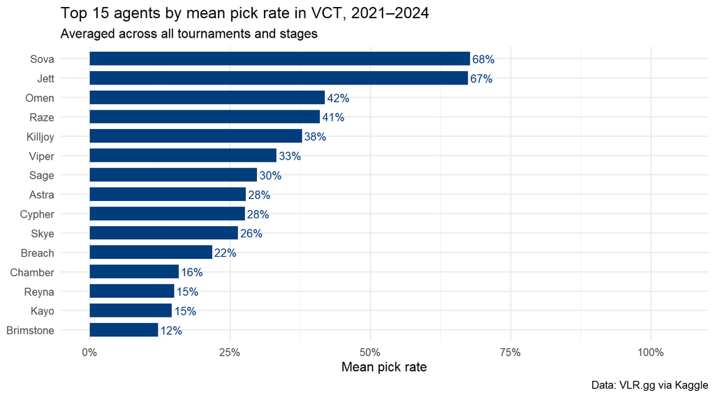

```r
# Top agents by mean pick rate across all years
top_agents <- pick_rates %>%
  group_by(agent) %>%
  summarise(mean_pick = mean(pick_rate, na.rm = TRUE),
            .groups = "drop") %>%
  arrange(desc(mean_pick)) %>%
  slice_head(n = 15)

ggplot(top_agents, aes(x = mean_pick,
                       y = reorder(agent, mean_pick))) +
  geom_col(fill = "#003D7C", width = 0.7) +
  geom_text(aes(label = paste0(round(mean_pick * 100), "%")),
            hjust = -0.1, size = 3.5, colour = "#003D7C") +
  scale_x_continuous(
    labels = percent_format(),
    limits = c(0, 1.05)
  ) +
  labs(
    title   = "Top 15 agents by mean pick rate in VCT, 2021–2024",
    subtitle = "Averaged across all tournaments and stages",
    x       = "Mean pick rate",
    y       = NULL,
    caption = "Data: VLR.gg via Kaggle"
  )
```

### Insight 2: How has the meta evolved year by year? (Ridge plot)

Each year’s pick rate distribution shows how diverse or concentrated agent selection was in that season.

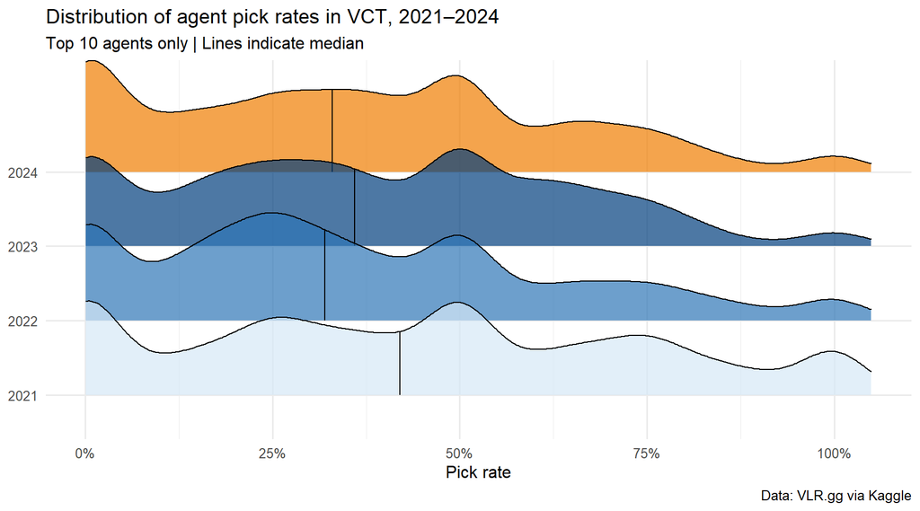

```r
# Focus on top 10 most picked agents overall
top10 <- top_agents %>% slice_head(n = 10) %>% pull(agent)

pick_rates %>%
  filter(agent %in% top10) %>%
  mutate(year = factor(year)) %>%
  ggplot(aes(x = pick_rate, y = year, fill = year)) +
  geom_density_ridges(alpha = 0.7, scale = 1.5,
                      quantile_lines = TRUE, quantiles = 2) +
  scale_x_continuous(labels = percent_format(), limits = c(0, 1.05)) +
  scale_fill_manual(values = c(
    "2021" = "#D6E8F7",
    "2022" = "#2E75B6",
    "2023" = "#003D7C",
    "2024" = "#EF7C00"
  ), guide = "none") +
  labs(
    title    = "Distribution of agent pick rates in VCT, 2021–2024",
    subtitle = "Top 10 agents only | Lines indicate median",
    x        = "Pick rate",
    y        = NULL,
    caption  = "Data: VLR.gg via Kaggle"
  )
```

### Insight 3: Are Valorant’s maps balanced between attack and defence?

A balanced map should have an attacker win rate close to 50%. Significant deviations suggest structural advantages for one side.

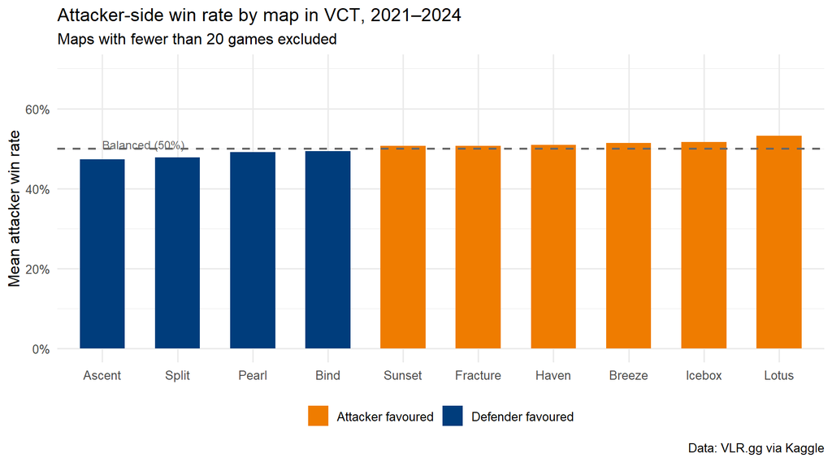

```r
map_balance <- maps_stats %>%
  group_by(map) %>%
  summarise(
    mean_atk = mean(atk_win, na.rm = TRUE),
    total_maps = sum(maps_played),
    .groups = "drop"
  ) %>%
  filter(total_maps >= 20) %>%
  mutate(
    balance   = mean_atk - 0.5,
    advantage = if_else(balance > 0, "Attacker favoured", "Defender favoured")
  )

ggplot(map_balance, aes(x = reorder(map, balance),
                        y = mean_atk,
                        fill = advantage)) +
  geom_col(width = 0.6) +
  geom_hline(yintercept = 0.5, linetype = "dashed",
             colour = "grey40", linewidth = 0.8) +
  annotate("text", x = 1, y = 0.51,
           label = "Balanced (50%)", hjust = 0,
           size = 3.2, colour = "grey40") +
  scale_fill_manual(values = c(
    "Attacker favoured" = "#EF7C00",
    "Defender favoured" = "#003D7C"
  )) +
  scale_y_continuous(labels = percent_format(), limits = c(0, 0.7)) +
  labs(
    title    = "Attacker-side win rate by map in VCT, 2021–2024",
    subtitle = "Maps with fewer than 20 games excluded",
    x        = NULL,
    y        = "Mean attacker win rate",
    fill     = NULL,
    caption  = "Data: VLR.gg via Kaggle"
  ) +
  theme(legend.position = "bottom")
```